# Romania: Renewable Energy Investments impact on Electricity Prices

Flavius Mihai Bendres

2025-04-21

# **Introduction**

This project analyzes the impact of renewable energy investments on the electricity prices in Romania by analysing the dual-mandate approach under the integrated national climate energy plan (NECP) under the two proposed scenarios. With additional measures (WAM), and With existing measures (WEM)

*To what extent does Romania’s renewable energy investments influence energy prices under the NECP’s WAM (With Additional Measures) and WEM (With Existing Measures) scenarios?*

Supporting research questions include:

*1. What are the implications of achieving or failing to meet Romania’s RES targets, as outlined in the NECP?*

*2. Are there any differences between the projected impacts of EU ETS carbon prices and Green Certificates on energy prices in Romania’s electricity generation sector, as outlined in the NECP?*

*3. How do the NECP’s WAM and WEM scenarios differ in their projected impacts on energy prices, particularly in the context of renewable energy investments and carbon pricing mechanisms?*

# **Data Cleaning, Preparation, and EDA**

```r
electricity_price <- electricity_price %>%
  mutate(Date = as.Date(Date, format = "%Y-%m-%d"))

# 1. Carbon Price Data
carbon_price <- carbon_price %>%
  mutate(Date = as.Date(Date, format = "%d/%m/%Y")) %>%
  select(Date, Carbon_Price)

gas_price <- gas_price %>%
  rename(GasPrice = 'Gas Price (EUR/GWh)')


mes_data <- mes_data %>%
  mutate(Date = as.Date(Date, format = "%Y-%m-%d"))
```

## **Function to check duplicates**

This is important especially when we’re aiming to merge the datasets to avoid the “many-to-many” relationship

```r
check_duplicates <- function(df, name) {
  dupes <- df %>%
    group_by(Date) %>%
    summarise(n = n()) %>%
    filter(n > 1)
  if (nrow(dupes) > 0) {
    message(paste0("Duplicates in ", name, ":"))
    print(dupes)
  }
}

check_duplicates(carbon_price, "carbon_price")
```

```
## # A tibble: 22 × 2
##    Date           n
##    <date>     <int>
##  1 2020-03-01     2
##  2 2020-10-01     2
##  3 2021-06-01     2
##  4 2021-10-01     2
##  5 2021-11-01     2
##  6 2021-12-01     3
##  7 2022-01-01     2
##  8 2022-02-01     2
##  9 2022-03-01     8
## 10 2022-04-01     2
## # ℹ 12 more rows
```

```r
check_duplicates(electricity_price, "electricity_price")
check_duplicates(mes_data, "mes_data")
check_duplicates(green_certificates, "green_certificates")
check_duplicates(gas_price, "gas_price")
```

```
## # A tibble: 5 × 2
##   Date                    n
##   <dttm>              <int>
## 1 2019-12-01 00:00:00     2
## 2 2020-12-01 00:00:00     2
## 3 2021-12-01 00:00:00     2
## 4 2022-12-01 00:00:00     2
## 5 2023-11-01 00:00:00     2
```

```r
carbon_price <- carbon_price %>%
  group_by(Date) %>%
  summarise(Carbon_Price = mean(`Carbon_Price`))

gas_price <- gas_price %>%
  group_by(Date) %>%
  summarise(GasPrice = mean(`GasPrice`))
```

Gas prices were aggregated to daily averages from the Day-Ahead Market to align with the temporal resolution of other datasets. Remaining duplicate entries were resolved by retaining the mean value for each date to ensure a one-to-one relationship during merging.

## **Historical Electricity Prices**

### **Plot**

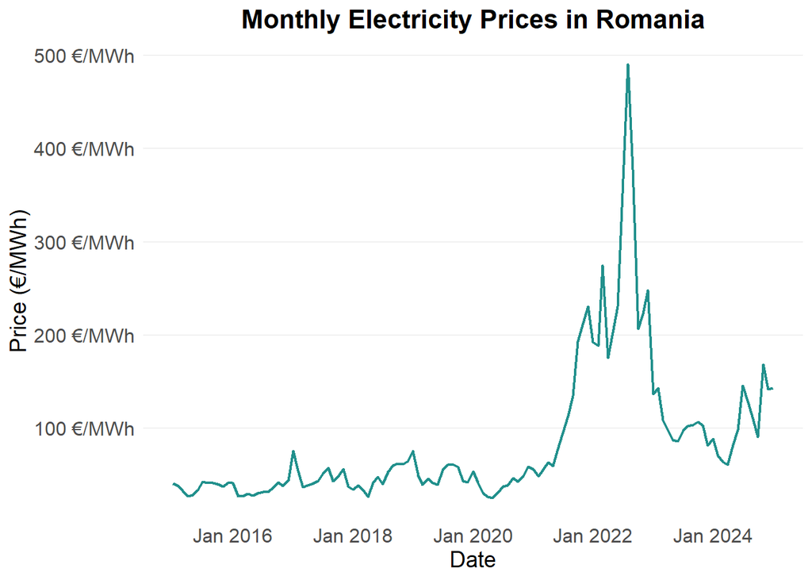

```r
ggplot(electricity_price, aes(x = Date, y = Electricity_Price)) +
  geom_line(color = "#21908CFF", linewidth = 0.8) +  # Use linewidth, not size
  labs(
    title = "Monthly Electricity Prices in Romania",
    x = "Date",
    y = "Price (€/MWh)"
  ) +
  scale_x_date(
    breaks = pretty_breaks(8),
    labels = date_format("%b %Y")
  ) +
  scale_y_continuous(
    labels = label_number(prefix = "", suffix = " €/MWh")
  ) +
  theme_minimal() +
  theme(
    plot.title = element_text(hjust = 0.5, size = 16, face = "bold"),
    axis.title = element_text(size = 14),
    axis.text = element_text(size = 12),
    panel.grid.major.y = element_line(color = "grey90", linewidth = 0.2),
    panel.grid.minor.y = element_blank(),
    panel.grid.major.x = element_blank(),
    panel.grid.minor.x = element_blank()
  )
```

Due to the observed extreme price fluctuations during the Russian-Ukraine war, we will analyze the period pre and post-war and conduct sensitivity analyses to arrive at the best data period.

## **Getting to understand the data**

### **Descriptive Statistics**

We can see that the table highlights the stability and trends in electricity prices under normal market conditions.

```r
# electricity prices under normal market conditions
library(openxlsx)

electricity_price_pre_war <- electricity_price %>%
  filter(Date >= "2015-01-01" & Date < "2022-03-01")

#descriptive statistics for each year (pre-war)
yearly_stats <- electricity_price_pre_war %>%
  mutate(Year = format(Date, "%Y")) %>%
  group_by(Year) %>%
  summarize(
    Mean = round(mean(Electricity_Price, na.rm = TRUE), 2),
    Std_dev = round(sd(Electricity_Price, na.rm = TRUE), 2),
    Min = round(min(Electricity_Price, na.rm = TRUE), 2),
    Max = round(max(Electricity_Price, na.rm = TRUE), 2),
    Freq = n()
  )

# total statistics (pre-war)
total_stats <- data.frame(
  Year = "Total",
  Mean = round(mean(electricity_price_pre_war$Electricity_Price, na.rm = TRUE), 2),
  Std_dev = round(sd(electricity_price_pre_war$Electricity_Price, na.rm = TRUE), 2),
  Min = round(min(electricity_price_pre_war$Electricity_Price, na.rm = TRUE), 2),
  Max = round(max(electricity_price_pre_war$Electricity_Price, na.rm = TRUE), 2),
  Freq = nrow(electricity_price_pre_war)
)

final_table <- rbind(yearly_stats, total_stats)
final_table
```

```
## # A tibble: 9 × 6
##   Year   Mean Std_dev   Min   Max  Freq
##   <chr> <dbl>   <dbl> <dbl> <dbl> <int>
## 1 2015   36.4    5.36  26.4  41.9    12
## 2 2016   33.1    6.18  26.1  43.1    12
## 3 2017   48.0   11.3   36.4  75.2    12
## 4 2018   46.4   13     26.0  64.2    12
## 5 2019   50.4   11.3   38.4  74.9    12
## 6 2020   39.5   10.7   24.8  58.4    12
## 7 2021  111.    66.3   48.1 230.     12
## 8 2022  190.     2.76 188.  192.      2
## 9 Total  55.3   41.1   24.8 230.     86
```

```r
# Create summary statistics by year
final_table_carbon <- carbon_price %>%
  filter(Date >= "2015-01-01" & Date < "2022-03-01")%>%
  mutate(Year = format(Date, "%Y")) %>%
  group_by(Year) %>%
  summarise(
    Mean = mean(Carbon_Price, na.rm = TRUE),
    SD = sd(Carbon_Price, na.rm = TRUE),
    Min = min(Carbon_Price, na.rm = TRUE),
    Max = max(Carbon_Price, na.rm = TRUE),
    Count = n()
  )

# Calculate total statistics
total_row <- carbon_price %>%
  summarise(
    Year = "Total",  # Label the row as "Total"
    Mean = mean(Carbon_Price, na.rm = TRUE),
    SD = sd(Carbon_Price, na.rm = TRUE),
    Min = min(Carbon_Price, na.rm = TRUE),
    Max = max(Carbon_Price, na.rm = TRUE),
    Count = n()
  )

# Append the total row to the grouped data
final_table_carbon <- bind_rows(final_table_carbon, total_row)

# Print the final table
print(final_table_carbon)
```

```
## # A tibble: 9 × 6
##   Year   Mean     SD   Min   Max Count
##   <chr> <dbl>  <dbl> <dbl> <dbl> <int>
## 1 2015   7.28  0.544  6.68  8.01    12
## 2 2016   5.03  0.538  4.31  6.42    12
## 3 2017   5.50  1.09   4.52  7.68    12
## 4 2018  14.9   3.98   8.46 20.3     12
## 5 2019  24.3   1.87  21.0  26.7     12
## 6 2020  24.5   3.75  18.9  31.1     12
## 7 2021  51.9  12.3   33.5  77.3     12
## 8 2022  89.0   4.43  85.9  92.2      2
## 9 Total 36.9  30.6    4.31 92.9    121
```

```r
# Green Certificates Prices
final_table_GC <- green_certificates %>%
  filter(Date >= "2015-01-01" & Date < "2022-03-01")%>%
  mutate(Year = format(Date, "%Y")) %>%
  group_by(Year) %>%
  summarise(
    Mean = mean(Weighted_Avg_Price_PCBCV , na.rm = TRUE),
    SD = sd(Weighted_Avg_Price_PCBCV , na.rm = TRUE),
    Min = min(Weighted_Avg_Price_PCBCV , na.rm = TRUE),
    Max = max(Weighted_Avg_Price_PCBCV , na.rm = TRUE),
    Count = n()
  )

# total statistics
total_stat_GC <- green_certificates %>%
  summarise(
    Year = "Total",
    Mean = mean(Weighted_Avg_Price_PCBCV, na.rm = TRUE),
    SD = sd(Weighted_Avg_Price_PCBCV, na.rm = TRUE),
    Min = min(Weighted_Avg_Price_PCBCV, na.rm = TRUE),
    Max = max(Weighted_Avg_Price_PCBCV, na.rm = TRUE),
    Count = n()
  )

# Append the total row to the grouped data
final_table_GC <- bind_rows(final_table_GC, total_stat_GC)

print(final_table_GC)
```

```
## # A tibble: 6 × 6
##   Year   Mean     SD   Min   Max Count
##   <chr> <dbl>  <dbl> <dbl> <dbl> <int>
## 1 2018   27.0 0.0874  26.7  27.0    12
## 2 2019   27.5 0.0492  27.3  27.5    12
## 3 2020   28.0 0.0491  27.9  28.1    12
## 4 2021   28.6 0.0852  28.3  28.6    12
## 5 2022   28.9 0.144   28.8  29.0     2
## 6 Total  28.3 0.831   26.7  29.3    84
```

```r
# Gas Prices
final_table_gas <- gas_price %>%
  filter(Date >= "2015-01-01" & Date < "2022-03-01")%>%
  mutate(Year = format(Date, "%Y")) %>%
  group_by(Year) %>%
  summarise(
    Mean = mean(GasPrice , na.rm = TRUE),
    SD = sd(GasPrice , na.rm = TRUE),
    Min = min(GasPrice , na.rm = TRUE),
    Max = max(GasPrice , na.rm = TRUE),
    Count = n()
  )

# Calculate total statistics
total_stat_gas <- gas_price %>%
  summarise(
    Year = "Total",  # Label the row as "Total"
    Mean = mean(GasPrice, na.rm = TRUE),
    SD = sd(GasPrice, na.rm = TRUE),
    Min = min(GasPrice, na.rm = TRUE),
    Max = max(GasPrice, na.rm = TRUE),
    Count = n()
  )

final_table_gas <- bind_rows(final_table_gas, total_stat_gas)

print(final_table_gas)
```

```
## # A tibble: 9 × 6
##   Year    Mean     SD    Min    Max Count
##   <chr>  <dbl>  <dbl>  <dbl>  <dbl> <int>
## 1 2015  21902.  4102. 17481. 28533.    12
## 2 2016  14183.  1820. 12458. 17682.    12
## 3 2017  16142.   841. 14869. 17682.    12
## 4 2018  17667.  4342. 14980  26590     12
## 5 2019  18109.  3303. 13620. 22890     12
## 6 2020  21028.  4100. 13464. 25030.    12
## 7 2021  42258. 23640. 16005. 88839.    12
## 8 2022  82348.   973. 81660. 83036.     2
## 9 Total 33776. 25662. 12458. 96380.   120
```

```r
# Demand
final_table_demand <- demand %>%
  mutate(Year = format(Date, "%Y")) %>%
  group_by(Year) %>%
  summarise(
    Mean = mean(Consumption , na.rm = TRUE),
    SD = sd(Consumption , na.rm = TRUE),
    Min = min(Consumption , na.rm = TRUE),
    Max = max(Consumption , na.rm = TRUE),
    Count = n()
  )

# total statistics
total_stat_demand <- demand %>%
  summarise(
    Year = "Total",  # Label the row as "Total"
    Mean = mean(Consumption, na.rm = TRUE),
    SD = sd(Consumption, na.rm = TRUE),
    Min = min(Consumption, na.rm = TRUE),
    Max = max(Consumption, na.rm = TRUE),
    Count = n()
  )

final_table_demand <- bind_rows(final_table_demand, total_stat_demand)

print(final_table_demand)
```

```
## # A tibble: 9 × 6
##   Year   Mean    SD   Min   Max Count
##   <chr> <dbl> <dbl> <dbl> <dbl> <int>
## 1 2015  4563.  256.  4202  5023    12
## 2 2016  4615.  362.  4258  5226    12
## 3 2017  4731.  322.  4367  5441    12
## 4 2018  5062.  436.  4511  5694    12
## 5 2019  4990.  330.  4613  5763    12
## 6 2020  4825.  470.  4090  5558    12
## 7 2021  5077.  338.  4621  5586    12
## 8 2022  5159   488.  4814  5504     2
## 9 Total 4845.  405.  4090  5763    86
```

```r
# imports
final_table_imp <- imp_exp %>%
  mutate(Year = format(Date, "%Y")) %>%
  group_by(Year) %>%
  summarise(
    Mean = mean(Current_Gas_Imports , na.rm = TRUE),
    SD = sd(Current_Gas_Imports , na.rm = TRUE),
    Min = min(Current_Gas_Imports , na.rm = TRUE),
    Max = max(Current_Gas_Imports , na.rm = TRUE),
    Count = n()
  )

# total statistics
total_stat_imp <- imp_exp %>%
  summarise(
    Year = "Total",  # Label the row as "Total"
    Mean = mean(Current_Gas_Imports, na.rm = TRUE),
    SD = sd(Current_Gas_Imports, na.rm = TRUE),
    Min = min(Current_Gas_Imports, na.rm = TRUE),
    Max = max(Current_Gas_Imports, na.rm = TRUE),
    Count = n()
  )

final_table_imp <- bind_rows(final_table_imp, total_stat_imp)

print(final_table_imp)
```

```
## # A tibble: 9 × 6
##   Year   Mean    SD   Min   Max Count
##   <chr> <dbl> <dbl> <dbl> <dbl> <int>
## 1 2015   181.  237.     1   628    12
## 2 2016  1328. 1408.   169  4175    12
## 3 2017  1070. 1404.     4  3853    12
## 4 2018  1351. 1257.     3  3231    12
## 5 2019  2649. 1163.  1185  4896    12
## 6 2020  1944.  746.   861  3397    12
## 7 2021  3007. 1058.   235  4373    12
## 8 2022  3552   751.  3021  4083     2
## 9 Total 1691. 1413.     1  4896    86
```

The “Total” line highlights general trends of the dataset by combining all the years (or groups) together. It is a useful way for the reader to see the overarching patterns without the need of concentrating on the individual groups. It gives the possibility of making a direct comparison between statistics for individual groups that are, for example, given on a yearly basis, and the statistics for the whole dataset. In this way, it draws the attention to the deviations, anomalies, or the consistency in the data.

### **Data Exploration Graphs**

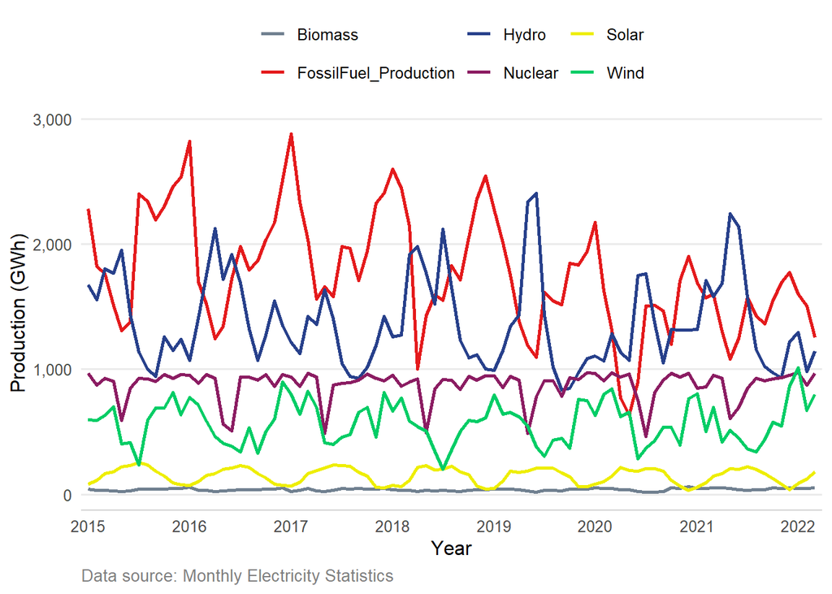

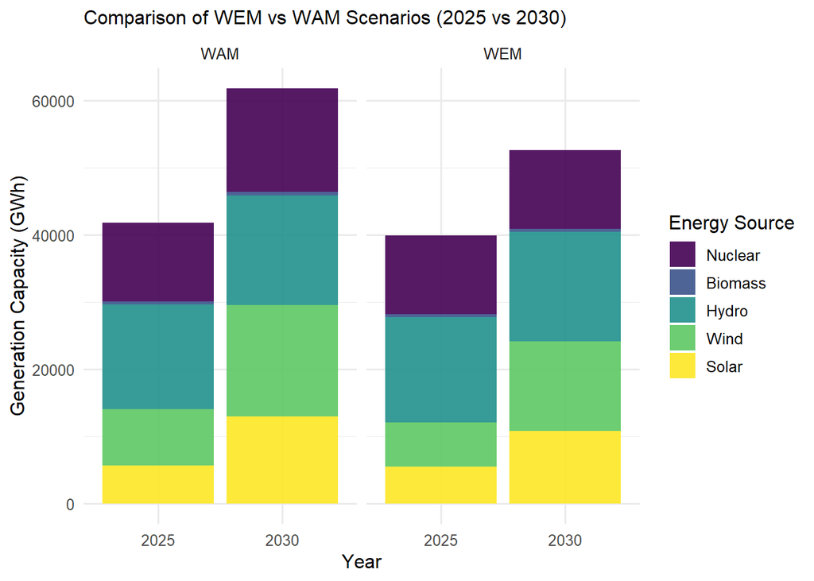

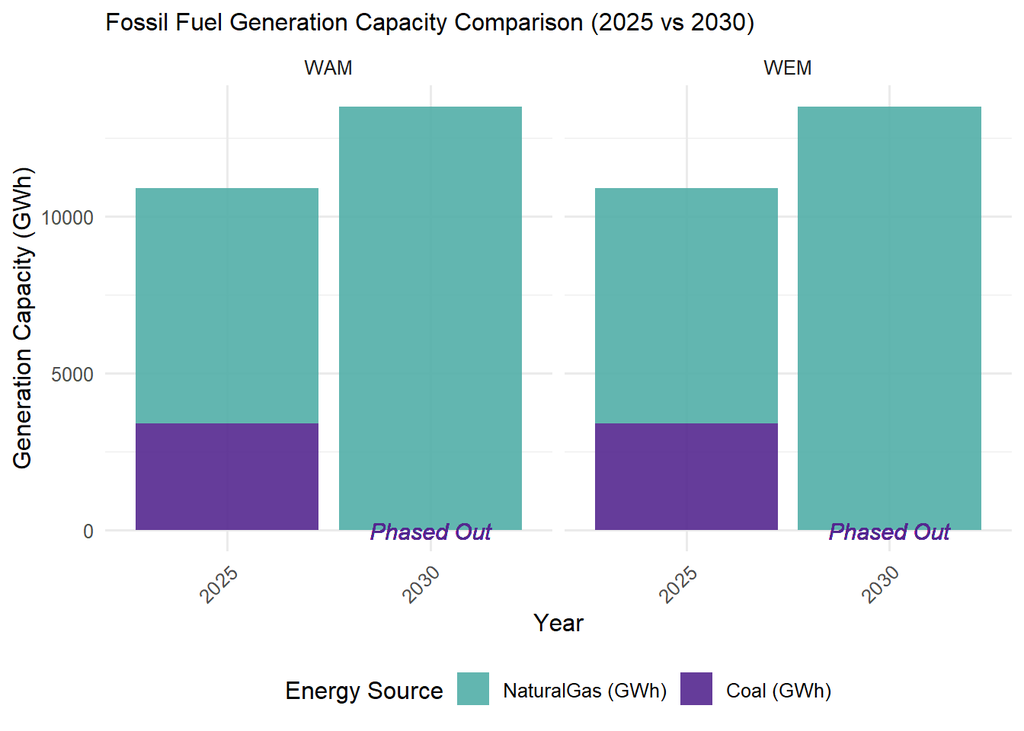

# **Joining the datasets**

```r
combined_data <- carbon_price %>%
  left_join(electricity_price, by = "Date") %>%
  left_join(mes_data, by = "Date") %>%
  left_join(gas_price, by = "Date") %>%
  #left_join(demand, by = "Date") %>%
  #left_join(imp_exp, by = "Date") %>%
  left_join(green_certificates, by = "Date") %>%
  mutate(Period = "Historical", Scenario = "Actual") %>%
  filter(Date <= as.Date("2022-02-28"))

emission_factors <- list(
  Coal = 334,
  NaturalGas = 205,
  biomass = 19
)

full_data <- combined_data %>%
  mutate(
    FossilFuel_Production = FossilFuel_Production - `Oil and Petroleum Products`,
    Carbon_Cost_Coal = Coal_Production * emission_factors$Coal * Carbon_Price,
    Carbon_Cost_NaturalGas = NaturalGas_Production * emission_factors$NaturalGas * Carbon_Price,
    #Carbon_Cost_CrudeOil = CrudeOil_Production * emission_factors$CrudeOil * Carbon_Price,
    Carbon_Cost_biomass = Biomass * emission_factors$biomass * Carbon_Price,

    # Total carbon cost (€/GWh)
    Total_Carbon_Cost = (Carbon_Cost_Coal + Carbon_Cost_NaturalGas + Carbon_Cost_biomass) / FossilFuel_Production,

    # Handle division by zero (if fossil fuel production is 0)
    Total_Carbon_Cost = ifelse(FossilFuel_Production == 0, 0, Total_Carbon_Cost)
  )

historical_data <- full_data

# log-transformed dependent variable
full_data <- full_data %>%
  mutate(log_Electricity_Price = log(Electricity_Price))
historical_data <- historical_data %>%
  mutate(log_Electricity_Price = log(Electricity_Price))

log_model_formula <- log_Electricity_Price ~ Total_Carbon_Cost + Weighted_Avg_Price_PCBCV + GasPrice + Wind + Solar + Hydro + Biomass +
  FossilFuel_Production + Nuclear

log_model <- lm(log_model_formula, data = full_data)
summary(log_model)
```

```
##
## Call:
## lm(formula = log_model_formula, data = full_data)
##
## Residuals:
##      Min       1Q   Median       3Q      Max
## -0.47472 -0.06859 -0.00001  0.07643  0.36129
##
## Coefficients:
##                              Estimate   Std. Error t value     Pr(>|t|)
## (Intercept)              11.071527797  2.585913465   4.281     0.000113 ***
## Total_Carbon_Cost         0.000104792  0.000016069   6.521 0.0000000875 ***
## Weighted_Avg_Price_PCBCV -0.281696704  0.090058425  -3.128     0.003278 **
## GasPrice                  0.000006027  0.000003177   1.897     0.065008 .
## Wind                     -0.000572115  0.000189217  -3.024     0.004347 **
## Solar                    -0.000170647  0.000763343  -0.224     0.824243
## Hydro                    -0.000243963  0.000075183  -3.245     0.002376 **
## Biomass                   0.005266972  0.003717882   1.417     0.164324
## FossilFuel_Production     0.000279984  0.000097801   2.863     0.006653 **
## Nuclear                  -0.000284529  0.000241560  -1.178     0.245805
## ---
## Signif. codes:  0 '***' 0.001 '**' 0.01 '*' 0.05 '.' 0.1 ' ' 1
##
## Residual standard error: 0.1589 on 40 degrees of freedom
##   (36 observations deleted due to missingness)
## Multiple R-squared:  0.932,  Adjusted R-squared:  0.9167
## F-statistic:  60.9 on 9 and 40 DF,  p-value: < 0.00000000000000022
```

```r
vif(log_model) # check for collinearity in the log model
```

```
##        Total_Carbon_Cost Weighted_Avg_Price_PCBCV                 GasPrice
##                12.951181                 6.468709                 7.194842
##                     Wind                    Solar                    Hydro
##                 2.104706                 4.380796                 1.791777
##                  Biomass    FossilFuel_Production                  Nuclear
##                 2.953334                 3.331253                 1.736551
```

We can see high multicolinearity between the Total Carbon and Weight AVG so why not solve this issue first? - It’s generally more logical to determine the appropriate timeframe before you start comparing different model specifications or variable choices. - Including or excluding certain years can significantly affect the model’s coefficients and performance metrics. - Deciding on the appropriate timeframe first, we ensure that the subsequent variable selection is based on a consistent and well-defined dataset.

## **Sensitivity Analysis**

This will allow us to determine which variable (Carbon Price or Green Certificates) is a better predictor of electricity prices within the chosen timeframe (2015-February 2022).

Separate Historical and Projection Datasets: - One for historical data (2015–2024) with variables like energy prices, carbon prices, etc. - A second dataset for projected data (2025–2050) containing RES investments under WEM and WAM scenarios and fossil fuel production projections.

### **SA Electricity Timeframe**

```r
# Dataset excluding 2021 and 2022
reduced_data <- historical_data %>% filter(Date < as.Date("2021-01-01"))

log_model_full_historical <- lm(log_model_formula, data = historical_data)
summary(log_model_full_historical)
```

```
##
## Call:
## lm(formula = log_model_formula, data = historical_data)
##
## Residuals:
##      Min       1Q   Median       3Q      Max
## -0.47472 -0.06859 -0.00001  0.07643  0.36129
##
## Coefficients:
##                              Estimate   Std. Error t value     Pr(>|t|)
## (Intercept)              11.071527797  2.585913465   4.281     0.000113 ***
## Total_Carbon_Cost         0.000104792  0.000016069   6.521 0.0000000875 ***
## Weighted_Avg_Price_PCBCV -0.281696704  0.090058425  -3.128     0.003278 **
## GasPrice                  0.000006027  0.000003177   1.897     0.065008 .
## Wind                     -0.000572115  0.000189217  -3.024     0.004347 **
## Solar                    -0.000170647  0.000763343  -0.224     0.824243
## Hydro                    -0.000243963  0.000075183  -3.245     0.002376 **
## Biomass                   0.005266972  0.003717882   1.417     0.164324
## FossilFuel_Production     0.000279984  0.000097801   2.863     0.006653 **
## Nuclear                  -0.000284529  0.000241560  -1.178     0.245805
## ---
## Signif. codes:  0 '***' 0.001 '**' 0.01 '*' 0.05 '.' 0.1 ' ' 1
##
## Residual standard error: 0.1589 on 40 degrees of freedom
##   (36 observations deleted due to missingness)
## Multiple R-squared:  0.932,  Adjusted R-squared:  0.9167
## F-statistic:  60.9 on 9 and 40 DF,  p-value: < 0.00000000000000022
```

```r
log_model_reduced <- lm(log_model_formula, data = reduced_data)
summary(log_model_reduced)
```

```
##
## Call:
## lm(formula = log_model_formula, data = reduced_data)
##
## Residuals:
##      Min       1Q   Median       3Q      Max
## -0.25456 -0.06510 -0.00050  0.05958  0.36813
##
## Coefficients:
##                              Estimate   Std. Error t value    Pr(>|t|)
## (Intercept)              13.032428176  2.681251853   4.861 0.000048554 ***
## Total_Carbon_Cost         0.000136702  0.000021222   6.442 0.000000796 ***
## Weighted_Avg_Price_PCBCV -0.366797119  0.093577408  -3.920    0.000576 ***
## GasPrice                  0.000002128  0.000006275   0.339    0.737289
## Wind                     -0.000379930  0.000214036  -1.775    0.087595 .
## Solar                     0.000297193  0.000812090   0.366    0.717356
## Hydro                    -0.000224303  0.000080837  -2.775    0.010094 *
## Biomass                   0.005403912  0.003701802   1.460    0.156322
## FossilFuel_Production     0.000287272  0.000099926   2.875    0.007958 **
## Nuclear                  -0.000247722  0.000227876  -1.087    0.286972
## ---
## Signif. codes:  0 '***' 0.001 '**' 0.01 '*' 0.05 '.' 0.1 ' ' 1
##
## Residual standard error: 0.1373 on 26 degrees of freedom
##   (36 observations deleted due to missingness)
## Multiple R-squared:  0.8196, Adjusted R-squared:  0.7571
## F-statistic: 13.12 on 9 and 26 DF,  p-value: 0.0000001336
```

```r
reduced_model <- lm(Electricity_Price ~ Total_Carbon_Cost + Weighted_Avg_Price_PCBCV + GasPrice + Wind + Solar + Hydro + Biomass +
                                        FossilFuel_Production + Nuclear, data = reduced_data)

summary(reduced_model)
```

```
##
## Call:
## lm(formula = Electricity_Price ~ Total_Carbon_Cost + Weighted_Avg_Price_PCBCV +
##     GasPrice + Wind + Solar + Hydro + Biomass + FossilFuel_Production +
##     Nuclear, data = reduced_data)
##
## Residuals:
##      Min       1Q   Median       3Q      Max
## -13.6049  -2.8883   0.1644   2.1237  21.4950
##
## Coefficients:
##                              Estimate   Std. Error t value   Pr(>|t|)
## (Intercept)              500.49000723 133.04932631   3.762   0.000868 ***
## Total_Carbon_Cost          0.00578489   0.00105307   5.493 0.00000919 ***
## Weighted_Avg_Price_PCBCV -17.59205040   4.64350678  -3.789   0.000810 ***
## GasPrice                   0.00020653   0.00031139   0.663   0.513009
## Wind                      -0.01613112   0.01062090  -1.519   0.140878
## Solar                      0.00001593   0.04029761   0.000   0.999688
## Hydro                     -0.01174862   0.00401129  -2.929   0.006990 **
## Biomass                    0.18825815   0.18369114   1.025   0.314869
## FossilFuel_Production      0.00952691   0.00495855   1.921   0.065720 .
## Nuclear                   -0.00834103   0.01130769  -0.738   0.467337
## ---
## Signif. codes:  0 '***' 0.001 '**' 0.01 '*' 0.05 '.' 0.1 ' ' 1
##
## Residual standard error: 6.811 on 26 degrees of freedom
##   (36 observations deleted due to missingness)
## Multiple R-squared:  0.7711, Adjusted R-squared:  0.6918
## F-statistic:  9.73 on 9 and 26 DF,  p-value: 0.000002434
```

```r
coefficients_log_full <- coef(log_model_full_historical)
coefficients_log_reduced <- coef(log_model_reduced)
print("Coefficients - Full Historical Model (Log Scale):")
```

```
## [1] "Coefficients - Full Historical Model (Log Scale):"
```

```r
print(coefficients_log_full)
```

```
##              (Intercept)        Total_Carbon_Cost Weighted_Avg_Price_PCBCV
##          11.071527796527           0.000104791853          -0.281696703514
##                 GasPrice                     Wind                    Solar
##           0.000006027388          -0.000572114795          -0.000170647425
##                    Hydro                  Biomass    FossilFuel_Production
##          -0.000243963347           0.005266972299           0.000279983641
##                  Nuclear
##          -0.000284528819
```

```r
print("Coefficients - Reduced Model (Log Scale):")
```

```
## [1] "Coefficients - Reduced Model (Log Scale):"
```

```r
print(coefficients_log_reduced)
```

```
##              (Intercept)        Total_Carbon_Cost Weighted_Avg_Price_PCBCV
##          13.032428175773           0.000136701840          -0.366797118616
##                 GasPrice                     Wind                    Solar
##           0.000002127642          -0.000379929540           0.000297192841
##                    Hydro                  Biomass    FossilFuel_Production
##          -0.000224303436           0.005403912392           0.000287271925
##                  Nuclear
##          -0.000247722061
```